# Work Absenteeism

Catherine Williams & Others

March 29, 2019

# Project Description

Create a multivariate prediction model and perform data analyis of a dataset you choose. This can be either a linear regression, or a classification. This includes:

- Create 2 charts exploring the data with respect to the prediction variable (label)
- Create a hypothesis and perform a t.test to reject or fail to reject that hypothesis
- Split the data into training set and testing set for each model and wrangle the data as desired
- Create 2 prediction models of your chosen type (regression | classification), with at least one multivariate model including visualizing the results of each model
- Compare the performance of your models
- Include a written analysis of your prediction referencing using data to support your conclusions.

# Dataset

Data came from the UCI Machine Learning Repository. The data contains records of absenteeism at work for a courier company in Brazil.

# Setup

```r
# Load libraries
library(lubridate)
library(tidyverse)
library(modeest)
library(forcats)

# set.seed for reproducible results
set.seed(1222)
```

# Load and explore data structure

```r
#import data
url <-"https://archive.ics.uci.edu/ml/machine-learning-databases/00445/Absenteeism_at_work_AAA.zip"

temp <- tempfile()
temp2 <- tempfile()

download.file(url, temp)
unzip(zipfile = temp, exdir = temp2)
df <- read_csv2(file.path(temp2, "Absenteeism_at_work.csv"))

names(df) <- df %>% names() %>% str_replace_all(' |/', '_')
df %>% write_csv("Absenteeism_at_work.csv")

#review data
df %>% glimpse()
```

```
Observations: 740
Variables: 21
$ ID                              <int> 11, 36, 3, 7, 11, 3, 10, 20, 14, 1,...
$ Reason_for_absence              <int> 26, 0, 23, 7, 23, 23, 22, 23, 19, 2...
$ Month_of_absence                <int> 7, 7, 7, 7, 7, 7, 7, 7, 7, 7, 7, 7,...
$ Day_of_the_week                 <int> 3, 3, 4, 5, 5, 6, 6, 6, 2, 2, 2, 3,...
$ Seasons                         <int> 1, 1, 1, 1, 1, 1, 1, 1, 1, 1, 1, 1,...
$ Transportation_expense          <int> 289, 118, 179, 279, 289, 179, 361, ...
$ Distance_from_Residence_to_Work <int> 36, 13, 51, 5, 36, 51, 52, 50, 12, ...
$ Service_time                    <int> 13, 18, 18, 14, 13, 18, 3, 11, 14, ...
$ Age                             <int> 33, 50, 38, 39, 33, 38, 28, 36, 34,...
$ Work_load_Average_day           <dbl> 239554, 239554, 239554, 239554, 239...
$ Hit_target                      <int> 97, 97, 97, 97, 97, 97, 97, 97, 97,...
$ Disciplinary_failure            <int> 0, 1, 0, 0, 0, 0, 0, 0, 0, 0, 0, 0,...
$ Education                       <int> 1, 1, 1, 1, 1, 1, 1, 1, 1, 3, 1, 1,...
$ Son                             <int> 2, 1, 0, 2, 2, 0, 1, 4, 2, 1, 4, 4,...
$ Social_drinker                  <int> 1, 1, 1, 1, 1, 1, 1, 1, 1, 0, 1, 1,...
$ Social_smoker                   <int> 0, 0, 0, 1, 0, 0, 0, 0, 0, 0, 0, 0,...
$ Pet                             <int> 1, 0, 0, 0, 1, 0, 4, 0, 0, 1, 0, 0,...
$ Weight                          <int> 90, 98, 89, 68, 90, 89, 80, 65, 95,...
$ Height                          <int> 172, 178, 170, 168, 172, 170, 172, ...
$ Body_mass_index                 <int> 30, 31, 31, 24, 30, 31, 27, 23, 25,...
$ Absenteeism_time_in_hours       <int> 4, 0, 2, 4, 2, 2, 8, 4, 40, 8, 8, 8...
```

# Data processing

Create a new data frame(s) with appropriate data types and data cleaning for the data.

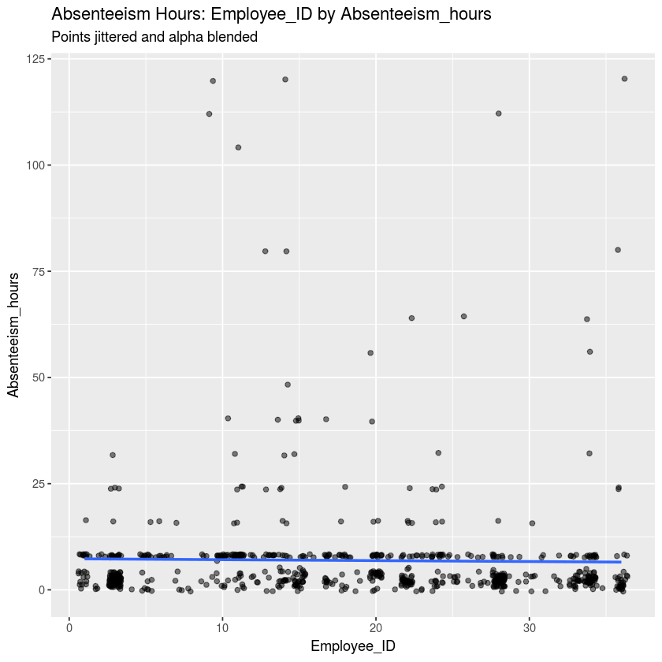

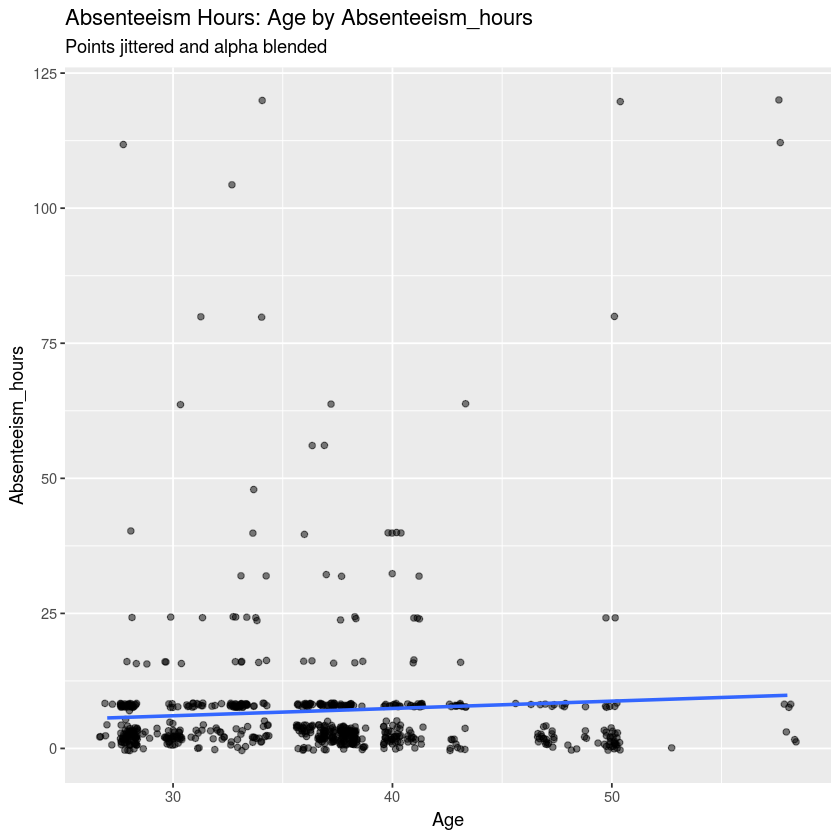

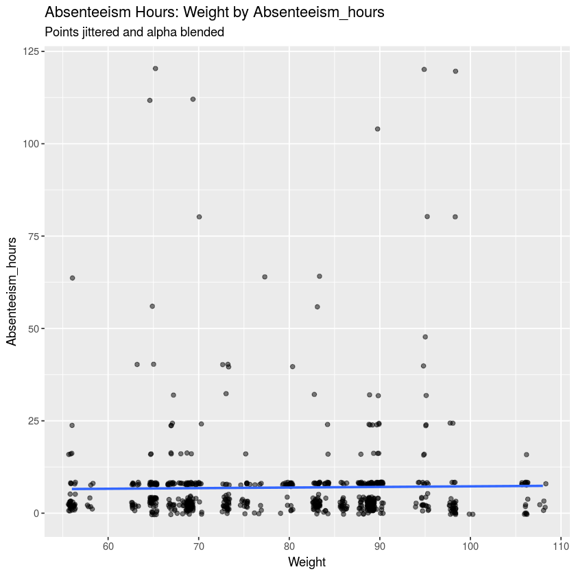

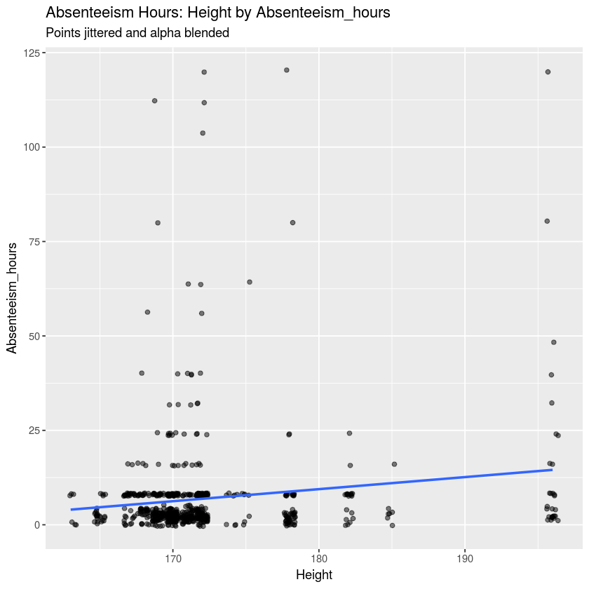

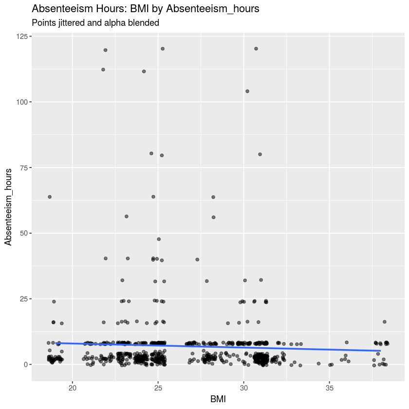

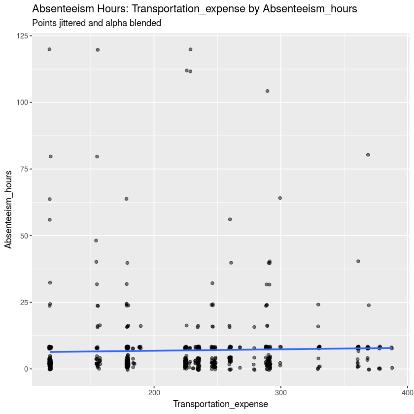

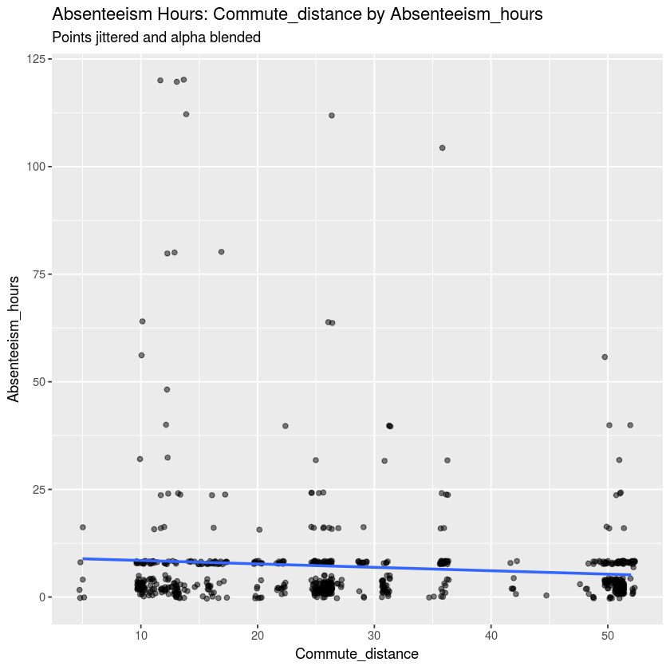

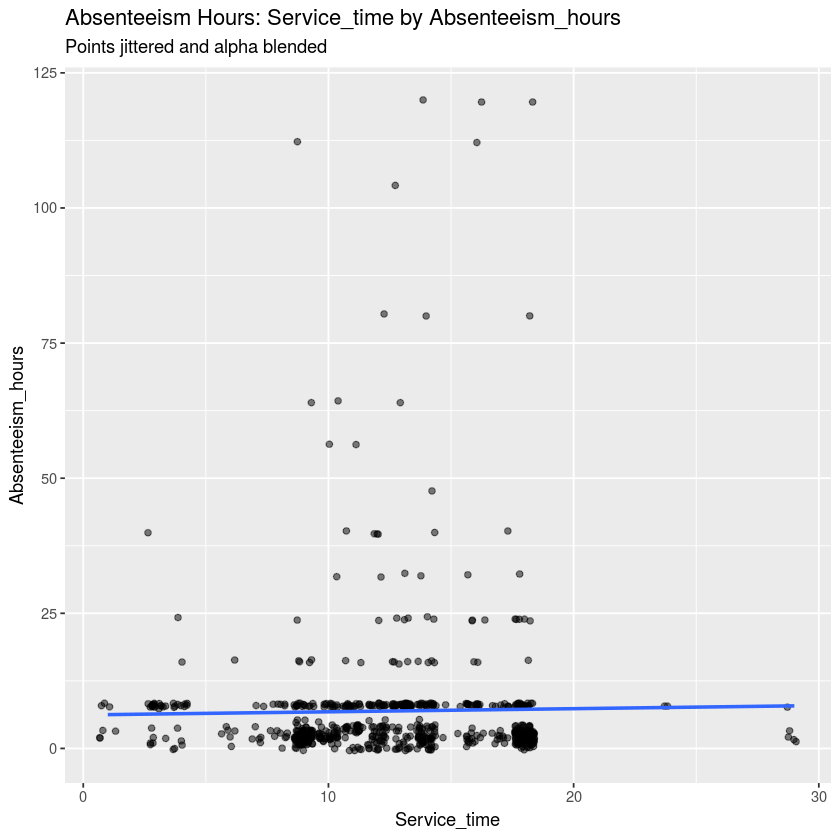

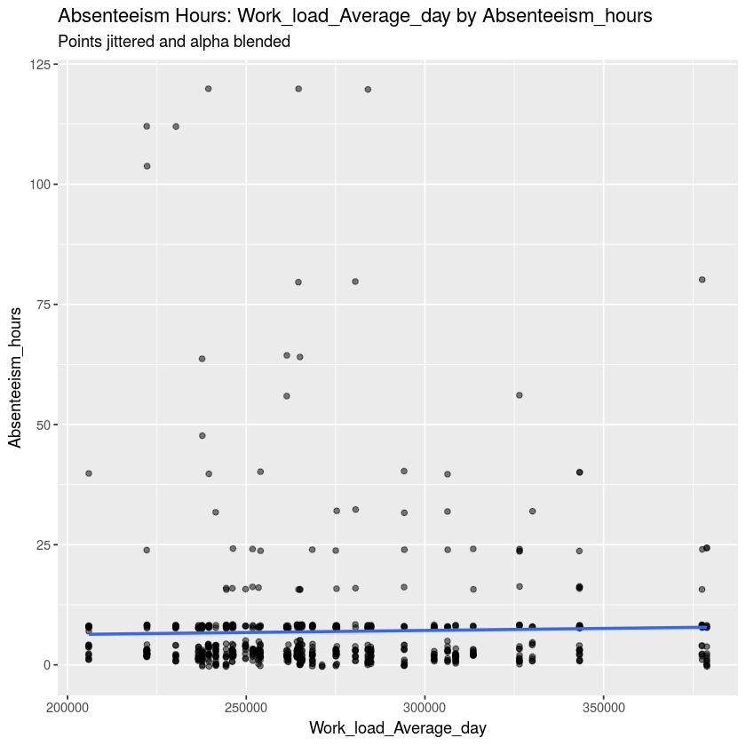

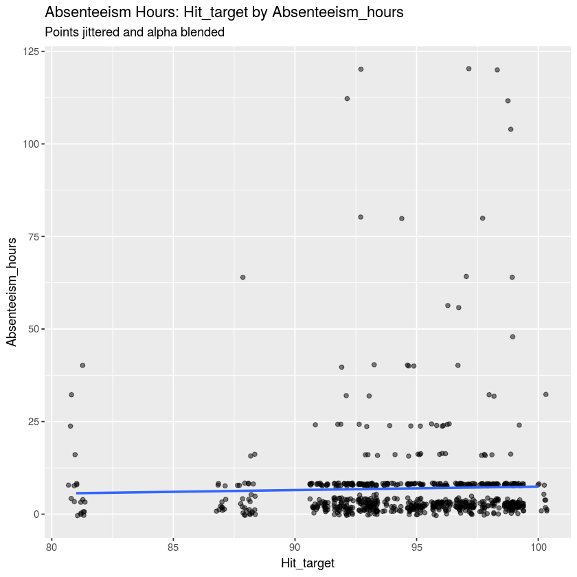

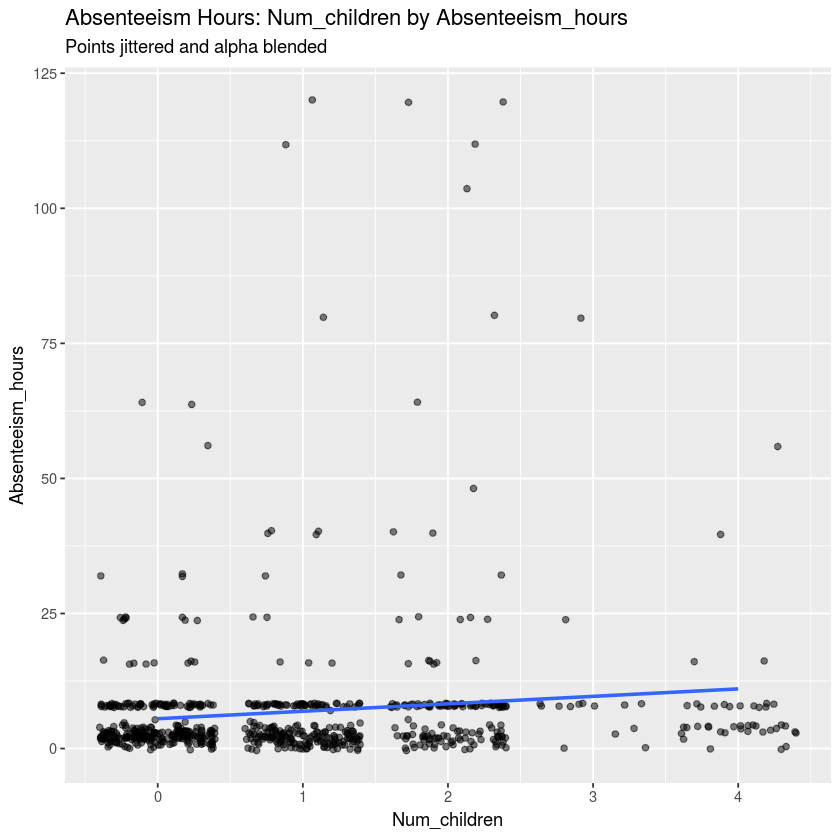

```
Absenteeism_hours mean: 6.92432432432432
Absenteeism_hours median: 3
Absenteeism_hours mode: 8
Absenteeism_hours variance: 177.715510368284
Absenteeism_hours std. deviation: 13.3309981009782
Absenteeism_hours std. error: 0.490057236547198
```

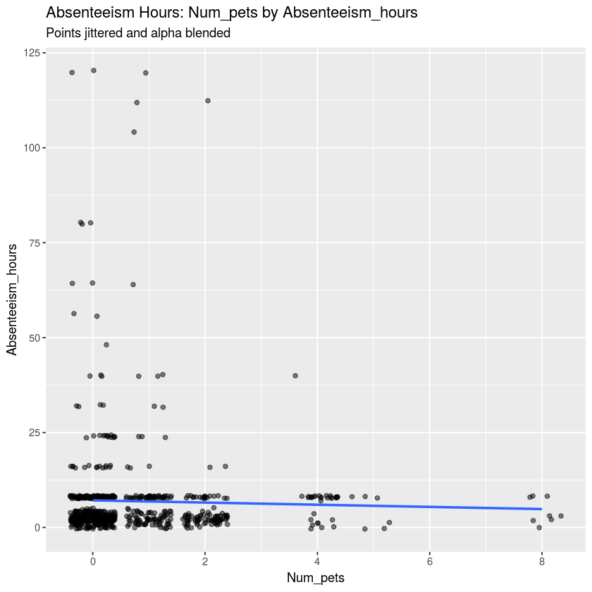

[8 more figures not shown]

```r
#change data types and column names
df <- df %>% mutate(PK = row_number(),
                      Employee_ID = ID,
                      Reason = as.factor(Reason_for_absence),
                      Month = as.factor(Month_of_absence),
                      Day_of_week = as.character(Day_of_the_week),
                      Day_of_week = str_replace(Day_of_week, "2", "Monday"),
                      Day_of_week = str_replace(Day_of_week, "3", "Tuesday"),
                      Day_of_week = str_replace(Day_of_week, "4", "Wednesday"),
                      Day_of_week = str_replace(Day_of_week, "5", "Thursday"),
                      Day_of_week = str_replace(Day_of_week, "6", "Friday"),
                      Day_of_week = as.factor(Day_of_week),
                      Day_of_week = fct_relevel(Day_of_week, "Monday", "Tuesday", "Wednesday","Thursday", "Friday"),
                      Seasons = as.character(Seasons),
                      Seasons = str_replace(Seasons, "1", "Summer"),
                      Seasons = str_replace(Seasons, "2", "Autumn"),
                      Seasons = str_replace(Seasons, "3", "Winter"),
                      Seasons = str_replace(Seasons, "4", "Spring"),
                      Seasons = as.factor(Seasons),
                      Seasons = fct_relevel(Seasons, "Summer", "Autumn", "Winter", "Spring"),
                      Commute_distance = Distance_from_Residence_to_Work,
                      Disciplinary_failure = as.logical(Disciplinary_failure),
                      Education = as.character(Education),
                      Education = str_replace(Education, "1", "High_school"),
                      Education = str_replace(Education, "2", "Undergraduate"),
                      Education = str_replace(Education, "3", "Graduate"),
                      Education = str_replace(Education, "4", "Doctorate"),
                      Education = as.ordered(Education),
                      Education = fct_relevel(Education, "High_school", "Undergraduate", "Graduate", "Doctorate"),
                      Num_children = Son,
                      Social_drinker = as.logical(Social_drinker),
                      Social_smoker = as.logical(Social_smoker),
                      Num_pets = Pet,
                      BMI = Body_mass_index,
                      Absenteeism_hours = Absenteeism_time_in_hours)

df <- df %>% select(PK, Employee_ID, Reason, Month, Day_of_week, Seasons, Age, Education, Weight, Height, BMI,
                    Transportation_expense, Commute_distance, Service_time, Work_load_Average_day, Hit_target,
                    Disciplinary_failure, Num_children, Num_pets, Social_drinker, Social_smoker, Absenteeism_hours)

#look for basic trends
y_var <- "Absenteeism_hours"

gg_scatter <- function(data, x_col, y_var, color) {
    if(is.numeric(data[[x_col]])){
      plt <- data %>% ggplot(mapping=aes_string(x_col, y_var))+
        geom_jitter(alpha=0.5)+
        geom_smooth(method="lm", se=FALSE)+
        labs(title=str_c("Absenteeism Hours: ", x_col, " by ", y_var), subtitle="Points jittered and alpha blended")
      plt %>% print()
        }
}

y_col <- c("Absenteeism_hours|PK")
x_cols <- df %>% names()
x_cols <- x_cols[!str_detect(x_cols, y_col)]

x_cols %>% walk(gg_scatter, data=df, y_var=y_var)

#create new data frame for variables with trends
df <- df %>% select(PK, Education, Reason, Day_of_week, Seasons, BMI, Transportation_expense, Service_time, Commute_distance,
                    Age, Hit_target, Disciplinary_failure, Num_children, Num_pets, Social_drinker, Social_smoker,
                    Absenteeism_hours)

#group BMI values
normal <- df %>% filter(BMI >= 19, BMI <= 24) %>%
  select(PK, BMI) %>% rename(normal=BMI)
overweight <- df %>% filter(BMI >= 25, BMI <= 29) %>%
  select(PK, BMI) %>% rename(overweight=BMI)
obese <- df %>% filter(BMI >= 30, BMI <= 39) %>%
  select(PK, BMI) %>% rename(obese=BMI)

df <- df %>%
  left_join(normal, by="PK") %>%
  left_join(overweight, by="PK") %>%
  left_join(obese, by="PK")

df <- df %>%
  gather(key=BMI_status, value=bmi, normal:obese) %>%
  drop_na()

df <- df %>%
  mutate(BMI_status = as.ordered(BMI_status) %>%
           fct_relevel(c("normal", "overweight", "obese"))) %>%
  select(-BMI, -bmi)

#view central tendency statistics
mean <- mean(df$Absenteeism_hours)
cat(str_c(y_var, " mean: ", mean), "\n")
median <- median(df$Absenteeism_hours)
cat(str_c(y_var, " median: ", median), "\n")
mode <- mfv(df$Absenteeism_hours)
cat(str_c(y_var, " mode: ", mode), "\n")
cat(str_c(y_var, " variance: ", var(df$Absenteeism_hours)), "\n")
cat(str_c(y_var, " std. deviation: ", sd(df$Absenteeism_hours)), "\n")
cat(str_c(y_var, " std. error: ", sd(df$Absenteeism_hours) /
            sqrt(length(df$Absenteeism_hours))), "\n")

#look for more patterns/trends
gg_facet <- function(data, facet) {
  if(!is.numeric(data[[facet]])){
    plt <- data %>% ggplot(mapping=aes_string("Absenteeism_hours"))+
       geom_density(fill="blue")+
       facet_wrap(paste("~", facet))+
       labs(title="Density of Absenteeism hours",
         subtitle=str_c("facet by ", facet))
     plt %>% print()
      }
}

facets <- df %>% names()
facets <- facets[!str_detect(facets, y_col)]

for(facet in facets){
  gg_facet(data=df, facet)
}
```

# Explore prediction variable

## Chart 1

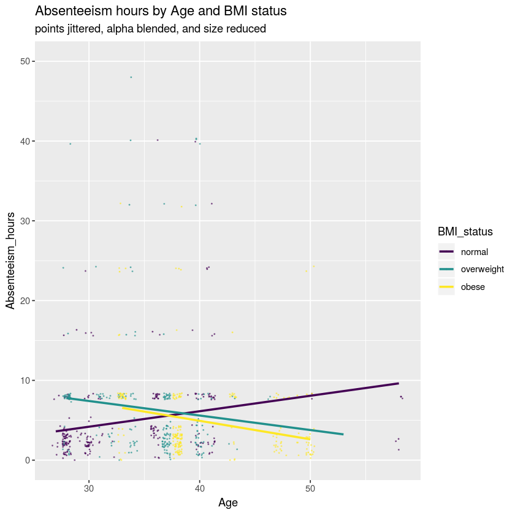

```r
#Would like to understand the correlation between age, BMI and absenteeism hours
df %>% ggplot(aes(Age, Absenteeism_hours, color=BMI_status))+
  geom_jitter(alpha=0.5,size=0.2)+
  geom_smooth(method="lm", se=FALSE)+
  ylim(0,50)+
  labs(title="Absenteeism hours by Age and BMI status", subtitle="points jittered, alpha blended, and size reduced")
```

### Analysis of Chart 1

For normal BMI status, absenteeism hours increase as age increases. For overweight and obese status, absenteeism hours tend to decrease as age increases. The different BMI status lines intersect at around 37 years old, meaning if someone is older than 37 with a normal BMI, they have an increased risk for greater absenteeism hours, compared to being younger or overweight/obese.

## Chart 2

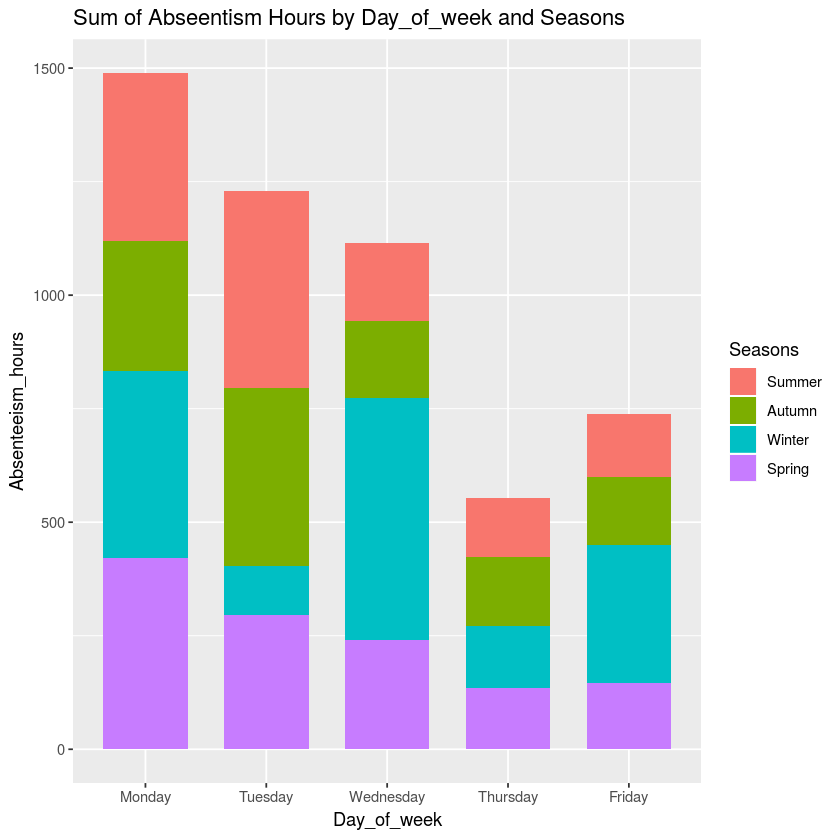

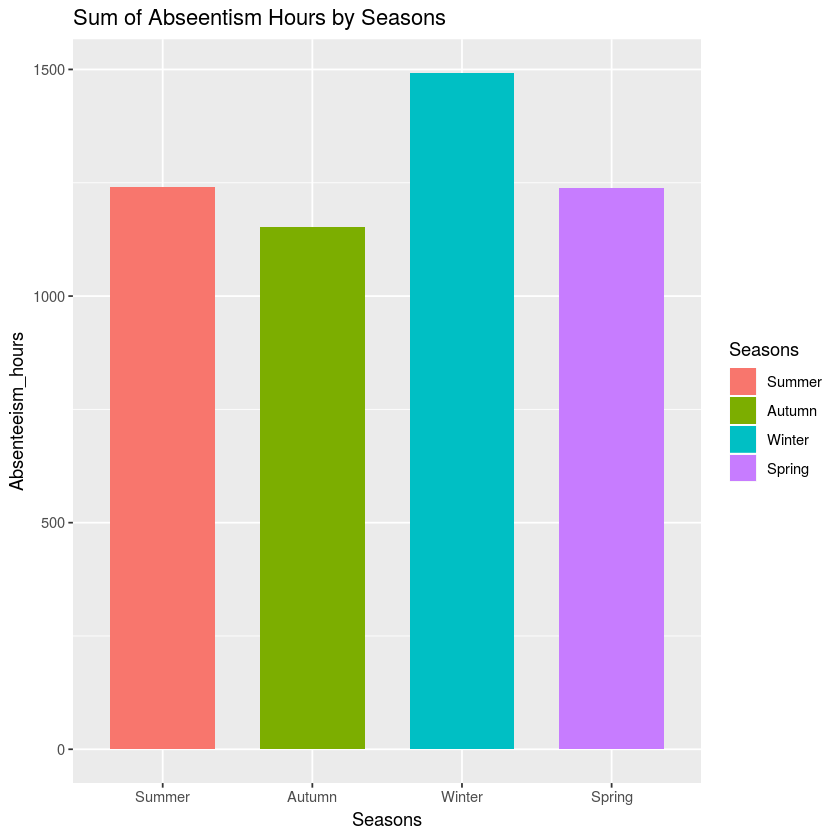

```r
#Would like to know which day of the week and seasons have the highest total absenteeism hours
df%>%ggplot(aes(x=Day_of_week,y=Absenteeism_hours,fill=Seasons))+
geom_col(width=0.7)+
labs(title="Sum of Abseentism Hours by Day_of_week and Seasons")

df%>%ggplot(aes(x=Seasons,y=Absenteeism_hours,fill=Seasons))+
geom_col(width=0.7)+
labs(title="Sum of Abseentism Hours by Seasons")
```

### Analysis of Chart 2

Mondays have the highest total absenteeism hours while Thursdays have the lowest. Winter has the highest absenteeism hours, at almost 1500 hours. Autumn has the lowest around 1150.

## Chart 3

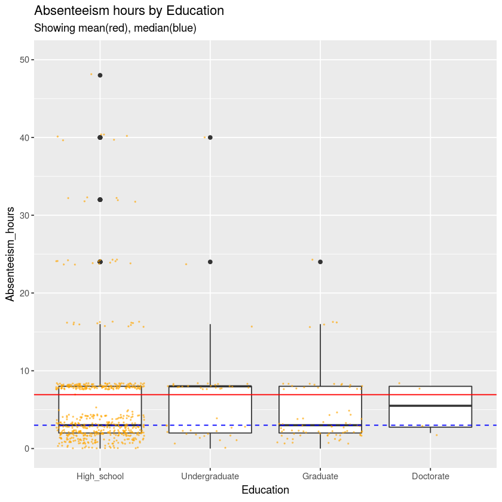

```r
#Would like to know correlation between Absenteeism hours and Education level
df %>% ggplot(aes(x=Education, y=Absenteeism_hours))+
  geom_boxplot()+
  ylim(0,50)+
  geom_jitter(alpha=0.5, color="orange", size=0.3)+
  geom_hline(yintercept=mean, color="red")+
  geom_hline(yintercept=median, color="blue",
             linetype="dashed")+
  labs(title="Absenteeism hours by Education", subtitle="Showing mean(red), median(blue)")
```

### Analysis of Chart 3

Further hypothesis testing will be done to understand whether mean absenteeism hours between different education levels are statistically significant.

# Hypothesis Testing

### Data frame preparation to do T-test among Education Levels

```r
df_High_school <- df %>% filter(Education == "High_school")
df_High_school%>%glimpse()
df_undergrad<- df %>% filter(Education == "Undergraduate")
df_undergrad%>%glimpse
df_grad <- df %>% filter(Education == "Graduate")
df_grad%>%glimpse

cat(str_c("High_school: mean = ", df_High_school$Absenteeism_hours %>% mean() %>% round(1)))

cat(str_c("Undergrad: mean = ", df_undergrad$Absenteeism_hours %>% mean() %>% round(1)))

cat(str_c("Graduate: mean = ", df_grad$Absenteeism_hours %>% mean() %>% round(1)))
```

```
Observations: 611
Variables: 17
$ PK                     <int> 4, 8, 11, 12, 13, 16, 24, 28, 38, 40, 41, 49...
$ Education              <ord> High_school, High_school, High_school, High_...
$ Reason                 <fct> 7, 23, 1, 1, 11, 14, 28, 28, 11, 23, 23, 22,...
$ Day_of_week            <fct> Thursday, Friday, Monday, Tuesday, Wednesday...
$ Seasons                <fct> Summer, Summer, Summer, Summer, Summer, Summ...
$ Transportation_expense <int> 279, 260, 260, 260, 260, 246, 260, 157, 291,...
$ Service_time           <int> 14, 11, 11, 11, 11, 16, 11, 6, 12, 11, 7, 11...
$ Commute_distance       <int> 5, 50, 50, 50, 50, 25, 50, 27, 50, 50, 42, 5...
$ Age                    <int> 39, 36, 36, 36, 36, 41, 36, 29, 32, 36, 27, ...
$ Hit_target             <int> 97, 97, 97, 97, 97, 97, 92, 92, 92, 92, 92, ...
$ Disciplinary_failure   <lgl> FALSE, FALSE, FALSE, FALSE, FALSE, FALSE, FA...
$ Num_children           <int> 2, 4, 4, 4, 4, 0, 4, 0, 0, 4, 0, 4, 4, 1, 1,...
$ Num_pets               <int> 0, 0, 0, 0, 0, 0, 0, 0, 0, 0, 0, 0, 0, 2, 2,...
```

[output cut: 43 more lines]

### Two Sided T Test

#### H Null: People with undergradudate and graduate degrees do not have different average absenteeism hours

#### H Alternative: The average absenteeism hours between people with undergraduate or graduate degrees are different

```r
t.test(df_undergrad$Absenteeism_hours, df_grad$Absenteeism_hours,conf.level=0.95,alternative="two.sided")
```

```
	Welch Two Sample t-test

data:  df_undergrad$Absenteeism_hours and df_grad$Absenteeism_hours
t = 0.84021, df = 106.91, p-value = 0.4027
alternative hypothesis: true difference in means is not equal to 0
95 percent confidence interval:
 -1.530001  3.780964
sample estimates:
mean of x mean of y
 6.391304  5.265823
```

As p-value of the t-test is greater than 0.05, we cannot reject the null hypothesis. Which means, according to these samples of the whole population, there is no statistically significant difference of average absenteeism hours between people with undergrad and graduate degrees.

### One sided T Test

#### H Null: People with high school degrees have fewer or the same average absenteeism hours than those with graduate degrees

#### H Alternative: The average absenteeism hours for people with high school degrees is higher than people with graduate degrees

```r
t.test(df_High_school$Absenteeism_hours, df_grad$Absenteeism_hours,conf.level=0.95,alternative="greater")
```

```
	Welch Two Sample t-test

data:  df_High_school$Absenteeism_hours and df_grad$Absenteeism_hours
t = 1.8057, df = 152.73, p-value = 0.03646
alternative hypothesis: true difference in means is greater than 0
95 percent confidence interval:
 0.1607247       Inf
sample estimates:
mean of x mean of y
 7.189853  5.265823
```

As p-value of the t-test is smaller than 0.05, we reject the null hypothesis. Which means, according to these samples of the whole population, the average absenteeism hours of those with high school degrees is higher than people with graduate degrees

# Variables preparation for training model

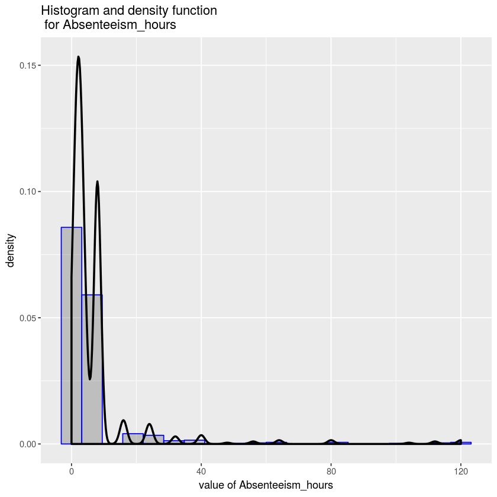

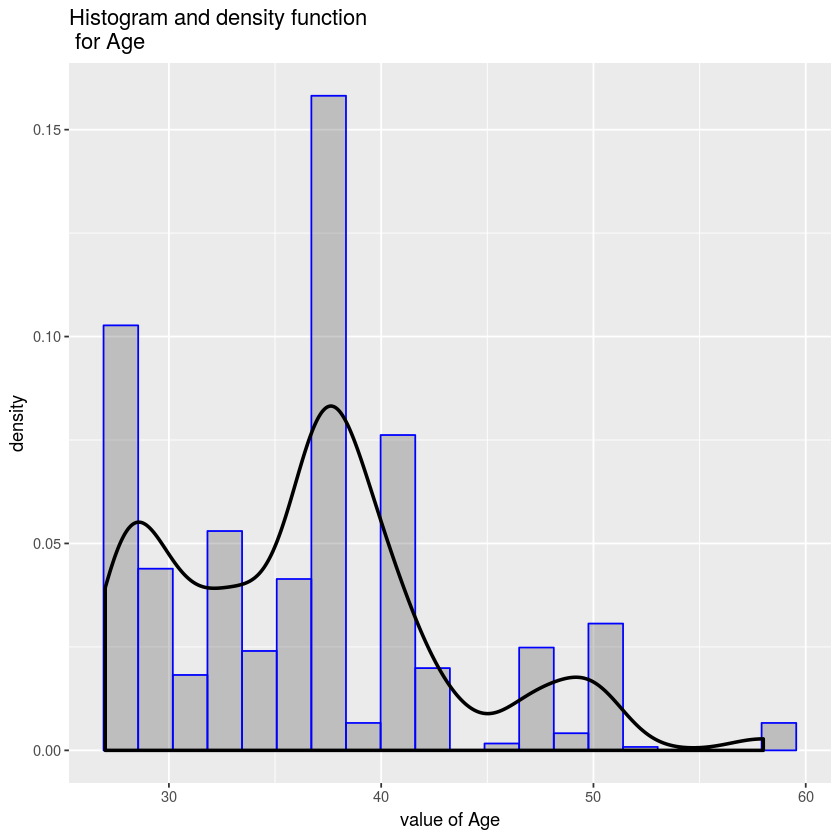

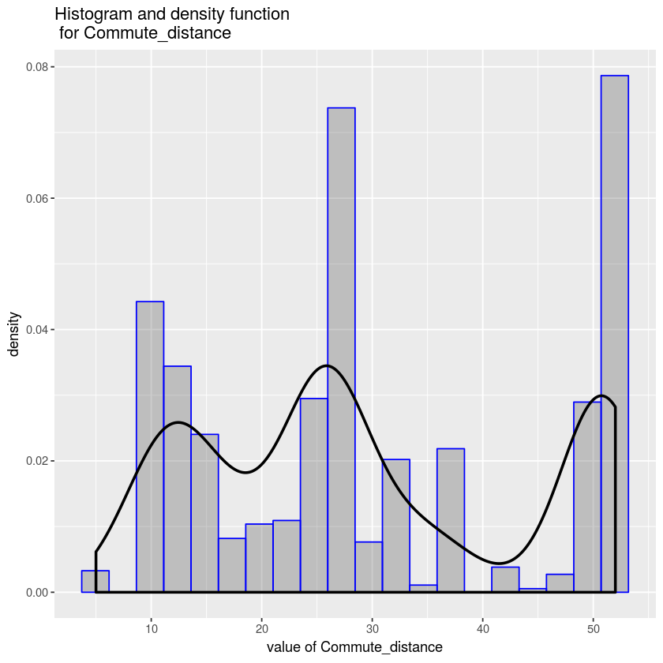

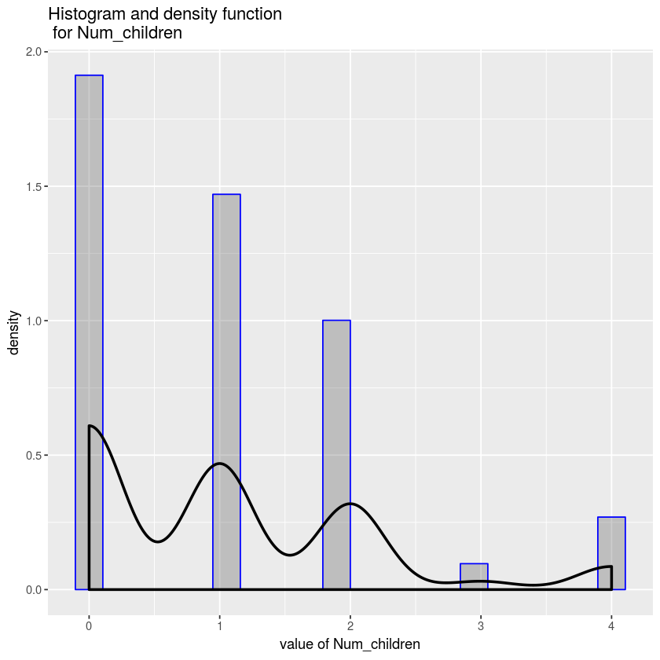

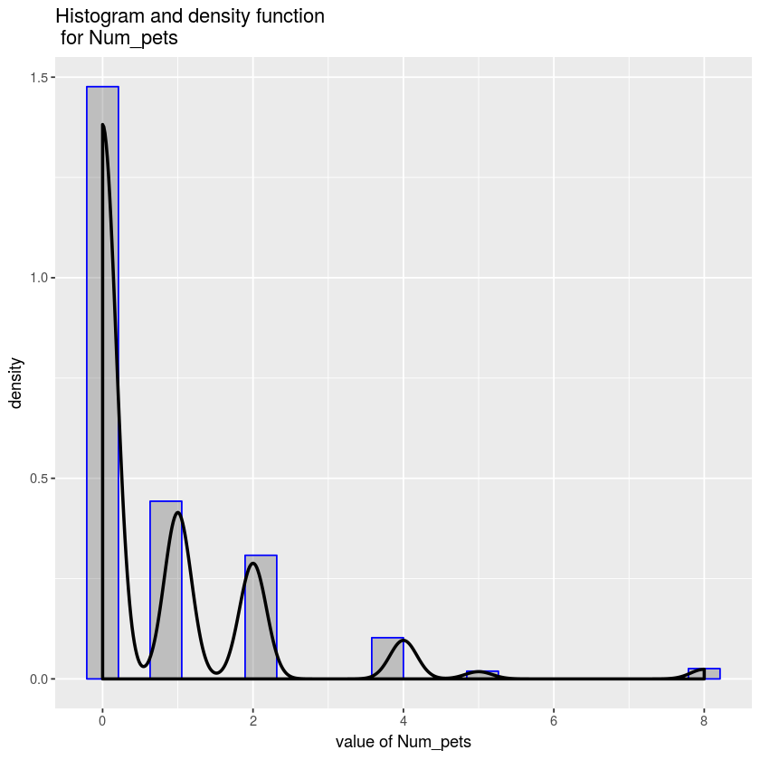

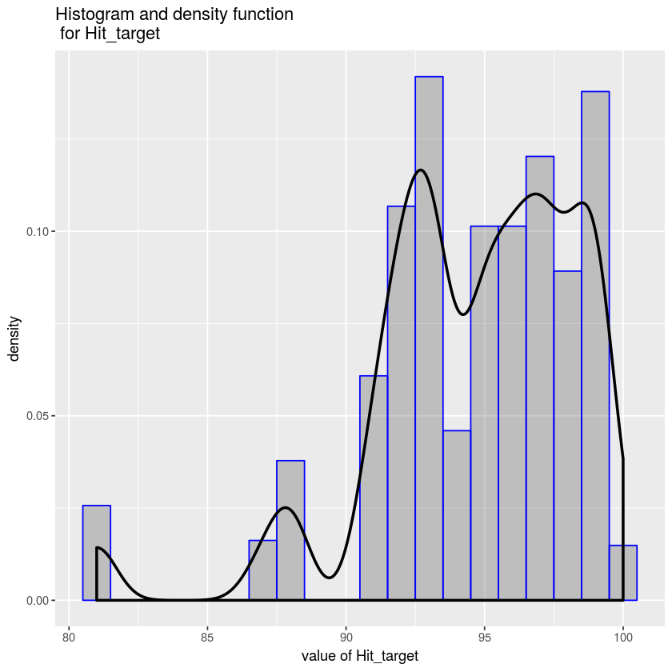

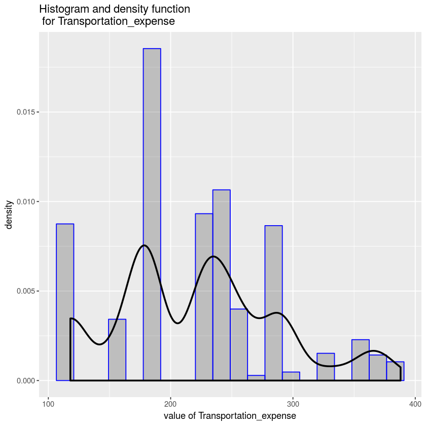

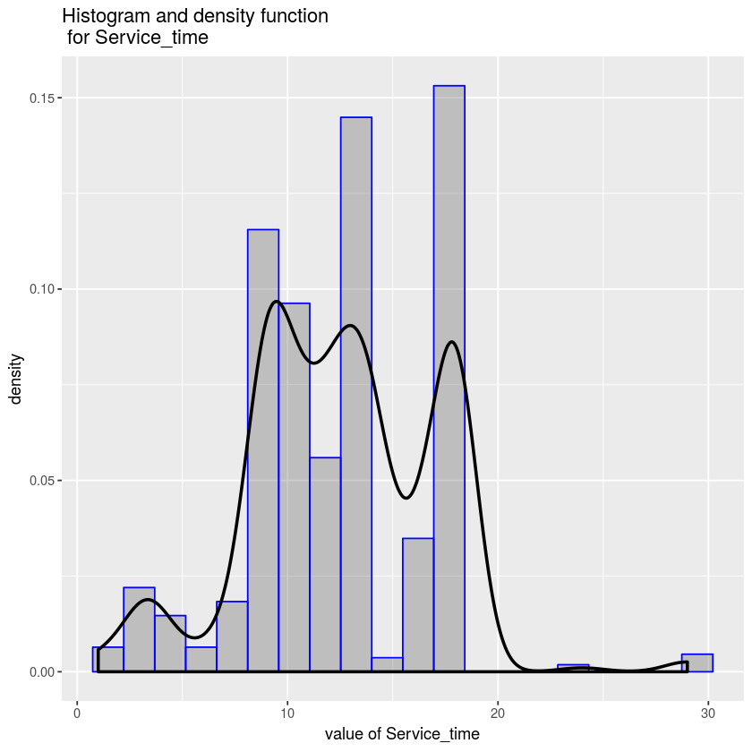

```r
#Loop plot the density of features
plot.hists <- function(col, df, bins = 20){
  p1 <- ggplot(df, aes_string(col)) +
    geom_histogram(aes(y = ..density..), bins = bins,
                   alpha = 0.3, color = 'blue') +
    geom_density(size = 1) +
    labs(title=str_c("Histogram and density function \n for ", col),
         x=str_c("value of ", col))

  p1 %>% print()
}

cols <- c('Absenteeism_hours', 'Age', 'Commute_distance','Num_children', 'Num_pets','Hit_target', 'Transportation_expense',
          'Service_time')

cols %>% walk(plot.hists, df)
```